# STAT 6021: Project 2

Connie Cui

11/26/2021

Load in packages

```r
library(tidyverse)
library(tidyverse)
library(ggplot2)
theme_set(theme_bw())
```

import data:

|  | id | date | price | bedrooms | bathrooms | sqft_living | sqft_lot | floors | waterfront | view | condition | grade | sqft_above | sqft_basement | yr_built | yr_renovated | zipcode | lat | long | sqft_living15 | sqft_lot15 | num |
| --- | --- | --- | --- | --- | --- | --- | --- | --- | --- | --- | --- | --- | --- | --- | --- | --- | --- | --- | --- | --- | --- | --- |
| 1 | 7129300520 | 20141013T000000 | 221900 | 3 | 1.00 | 1180 | 5650 | 1 | 0 | 0 | 3 | 7 | 1180 | 0 | 1955 | 0 | 98178 | 47.5112 | -122.257 | 1340 | 5650 | 1 |
| 2 | 6414100192 | 20141209T000000 | 538000 | 3 | 2.25 | 2570 | 7242 | 2 | 0 | 0 | 3 | 7 | 2170 | 400 | 1951 | 1991 | 98125 | 47.7210 | -122.319 | 1690 | 7639 | 1 |
| 3 | 5631500400 | 20150225T000000 | 180000 | 2 | 1.00 | 770 | 10000 | 1 | 0 | 0 | 3 | 6 | 770 | 0 | 1933 | 0 | 98028 | 47.7379 | -122.233 | 2720 | 8062 | 1 |
| 4 | 2487200875 | 20141209T000000 | 604000 | 4 | 3.00 | 1960 | 5000 | 1 | 0 | 0 | 5 | 7 | 1050 | 910 | 1965 | 0 | 98136 | 47.5208 | -122.393 | 1360 | 5000 | 1 |
| 5 | 1954400510 | 20150218T000000 | 510000 | 3 | 2.00 | 1680 | 8080 | 1 | 0 | 0 | 3 | 8 | 1680 | 0 | 1987 | 0 | 98074 | 47.6168 | -122.045 | 1800 | 7503 | 1 |
| 6 | 7237550310 | 20140512T000000 | 1230000 | 4 | 4.50 | 5420 | 101930 | 1 | 0 | 0 | 3 | 11 | 3890 | 1530 | 2001 | 0 | 98053 | 47.6561 | -122.005 | 4760 | 101930 | 1 |

find missing data:

| id | date | price | bedrooms | bathrooms | sqft_living | sqft_lot | floors | waterfront | view | condition | grade | sqft_above | sqft_basement | yr_built | yr_renovated | zipcode | lat | long | sqft_living15 | sqft_lot15 | num |
| --- | --- | --- | --- | --- | --- | --- | --- | --- | --- | --- | --- | --- | --- | --- | --- | --- | --- | --- | --- | --- | --- |

No missing data. Check data types of each variable:

```r
dim(house)
```

```
[1] 21613    22
```

We will definitely need to change the data type for the date column, and potentially look into creating factors for some of the more ordinal variables.

|  | id | date | price | bedrooms | bathrooms | sqft_living | sqft_lot | floors | waterfront | view | condition | grade | sqft_above | sqft_basement | yr_built | yr_renovated | zipcode | lat | long | sqft_living15 | sqft_lot15 | num |
| --- | --- | --- | --- | --- | --- | --- | --- | --- | --- | --- | --- | --- | --- | --- | --- | --- | --- | --- | --- | --- | --- | --- |
| 1 | 7129300520 | 20141013 | 221900 | 3 | 1.00 | 1180 | 5650 | 1 | 0 | 0 | 3 | 7 | 1180 | 0 | 1955 | 0 | 98178 | 47.5112 | -122.257 | 1340 | 5650 | 1 |
| 2 | 6414100192 | 20141209 | 538000 | 3 | 2.25 | 2570 | 7242 | 2 | 0 | 0 | 3 | 7 | 2170 | 400 | 1951 | 1991 | 98125 | 47.7210 | -122.319 | 1690 | 7639 | 1 |
| 3 | 5631500400 | 20150225 | 180000 | 2 | 1.00 | 770 | 10000 | 1 | 0 | 0 | 3 | 6 | 770 | 0 | 1933 | 0 | 98028 | 47.7379 | -122.233 | 2720 | 8062 | 1 |
| 4 | 2487200875 | 20141209 | 604000 | 4 | 3.00 | 1960 | 5000 | 1 | 0 | 0 | 5 | 7 | 1050 | 910 | 1965 | 0 | 98136 | 47.5208 | -122.393 | 1360 | 5000 | 1 |
| 5 | 1954400510 | 20150218 | 510000 | 3 | 2.00 | 1680 | 8080 | 1 | 0 | 0 | 3 | 8 | 1680 | 0 | 1987 | 0 | 98074 | 47.6168 | -122.045 | 1800 | 7503 | 1 |
| 6 | 7237550310 | 20140512 | 1230000 | 4 | 4.50 | 5420 | 101930 | 1 | 0 | 0 | 3 | 11 | 3890 | 1530 | 2001 | 0 | 98053 | 47.6561 | -122.005 | 4760 | 101930 | 1 |

Convert date variabe to date type:

|  | id | date | price | bedrooms | bathrooms | sqft_living | sqft_lot | floors | waterfront | view | condition | grade | sqft_above | sqft_basement | yr_built | yr_renovated | zipcode | lat | long | sqft_living15 | sqft_lot15 | num |
| --- | --- | --- | --- | --- | --- | --- | --- | --- | --- | --- | --- | --- | --- | --- | --- | --- | --- | --- | --- | --- | --- | --- |
| 1 | 7129300520 | 2014-10-13 | 221900 | 3 | 1.00 | 1180 | 5650 | 1 | 0 | 0 | 3 | 7 | 1180 | 0 | 1955 | 0 | 98178 | 47.5112 | -122.257 | 1340 | 5650 | 1 |
| 2 | 6414100192 | 2014-12-09 | 538000 | 3 | 2.25 | 2570 | 7242 | 2 | 0 | 0 | 3 | 7 | 2170 | 400 | 1951 | 1991 | 98125 | 47.7210 | -122.319 | 1690 | 7639 | 1 |
| 3 | 5631500400 | 2015-02-25 | 180000 | 2 | 1.00 | 770 | 10000 | 1 | 0 | 0 | 3 | 6 | 770 | 0 | 1933 | 0 | 98028 | 47.7379 | -122.233 | 2720 | 8062 | 1 |
| 4 | 2487200875 | 2014-12-09 | 604000 | 4 | 3.00 | 1960 | 5000 | 1 | 0 | 0 | 5 | 7 | 1050 | 910 | 1965 | 0 | 98136 | 47.5208 | -122.393 | 1360 | 5000 | 1 |
| 5 | 1954400510 | 2015-02-18 | 510000 | 3 | 2.00 | 1680 | 8080 | 1 | 0 | 0 | 3 | 8 | 1680 | 0 | 1987 | 0 | 98074 | 47.6168 | -122.045 | 1800 | 7503 | 1 |
| 6 | 7237550310 | 2014-05-12 | 1230000 | 4 | 4.50 | 5420 | 101930 | 1 | 0 | 0 | 3 | 11 | 3890 | 1530 | 2001 | 0 | 98053 | 47.6561 | -122.005 | 4760 | 101930 | 1 |

```r
house$waterfront <- factor(house$waterfront, ordered = TRUE, levels = c(0, 1))
```

[output not shown]

## Part 2: EDA

```r
#install.packages("ggcorrplot")
#install.packages("miscset")
library(miscset)
```

```r
names(house)
```

```
 [1] "id"            "date"          "price"         "bedrooms"      "bathrooms"     "sqft_living"   "sqft_lot"
 [8] "floors"        "waterfront"    "view"          "condition"     "grade"         "sqft_above"    "sqft_basement"
[15] "yr_built"      "yr_renovated"  "zipcode"       "lat"           "long"          "sqft_living15" "sqft_lot15"
[22] "num"
```

#### Prior to dropping Date and Geotags consider using them for plotting, for example transaction counts by dates?

```r
names(house)
```

```
 [1] "price"         "bedrooms"      "bathrooms"     "sqft_living"   "sqft_lot"      "floors"        "waterfront"
 [8] "view"          "condition"     "grade"         "sqft_above"    "sqft_basement" "yr_built"      "yr_renovated"
[15] "sqft_living15" "sqft_lot15"
```

```r
describe(house)
```

```
house

 16  Variables      21613  Observations
-----------------------------------------------------------------------------------------------------------------------------
price
       n  missing distinct     Info     Mean      Gmd      .05      .10      .25      .50      .75      .90      .95
   21613        0     3625        1   540182   329562   210000   245000   321950   450000   645000   887000  1160000

lowest :   75000   78000   80000   81000   82000, highest: 5350000 5570000 6890000 7060000 7700000
-----------------------------------------------------------------------------------------------------------------------------
bedrooms
       n  missing distinct     Info     Mean      Gmd      .05      .10      .25      .50      .75      .90      .95
   21613        0       13    0.871    3.371    0.946        2        2        3        3        4        4        5

lowest :  0  1  2  3  4, highest:  8  9 10 11 33

Value          0     1     2     3     4     5     6     7     8     9    10    11    33
Frequency     13   199  2760  9824  6882  1601   272    38    13     6     3     1     1
Proportion 0.001 0.009 0.128 0.455 0.318 0.074 0.013 0.002 0.001 0.000 0.000 0.000 0.000
-----------------------------------------------------------------------------------------------------------------------------
bathrooms
       n  missing distinct     Info     Mean      Gmd      .05      .10      .25      .50      .75      .90      .95
   21613        0       30    0.974    2.115   0.8444     1.00     1.00     1.75     2.25     2.50     3.00     3.50

lowest : 0.00 0.50 0.75 1.00 1.25, highest: 6.50 6.75 7.50 7.75 8.00
-----------------------------------------------------------------------------------------------------------------------------
sqft_living
       n  missing distinct     Info     Mean      Gmd      .05      .10      .25      .50      .75      .90      .95
   21613        0     1038        1     2080    978.4      940     1090     1427     1910     2550     3250     3760

lowest :   290   370   380   384   390, highest:  9640  9890 10040 12050 13540
-----------------------------------------------------------------------------------------------------------------------------
sqft_lot
       n  missing distinct     Info     Mean      Gmd      .05      .10      .25      .50      .75      .90      .95
   21613        0     9782        1    15107    17855     1800     3322     5040     7618    10688    21398    43339

lowest :     520     572     600     609     635, highest:  982998 1024068 1074218 1164794 1651359
-----------------------------------------------------------------------------------------------------------------------------
floors
       n  missing distinct     Info     Mean      Gmd
```

[output cut: 73 more lines]

```

For the frequency table, variable is rounded to the nearest 5
-----------------------------------------------------------------------------------------------------------------------------
sqft_living15
       n  missing distinct     Info     Mean      Gmd      .05      .10      .25      .50      .75      .90      .95
   21613        0      777        1     1987    743.2     1140     1256     1490     1840     2360     2930     3300

lowest :  399  460  620  670  690, highest: 5600 5610 5790 6110 6210
-----------------------------------------------------------------------------------------------------------------------------
sqft_lot15
       n  missing distinct     Info     Mean      Gmd      .05      .10      .25      .50      .75      .90      .95
   21613        0     8689        1    12768    13404     1999     3667     5100     7620    10083    17852    37063

lowest :    651    659    660    748    750, highest: 434728 438213 560617 858132 871200
-----------------------------------------------------------------------------------------------------------------------------
```

Summary plots:

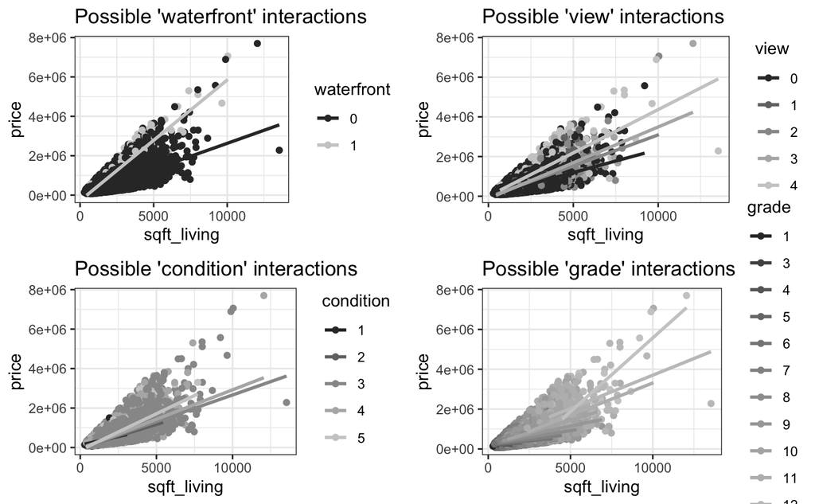

```r
##produce the 4 density plots in a 2 by 2 matrix
grid.arrange(sp1+scale_color_grey(),
             sp2+scale_color_grey(),
             sp3+scale_color_grey(),
             sp4+scale_color_grey(),
             ncol = 2,
             nrow = 2)
```

#### Question: how to deal with indicator (ordinary) varibales in this case? Map to binary classes:

[figure not shown]

```r
ggplotGrid(ncol = 2, lapply(c("view", "waterfront", "condition", "grade"),
    function(col) {
        ggplot(house, aes_string(col)) + geom_bar() + coord_flip()
    }))+ scale_color_grey()
```

[output not shown]

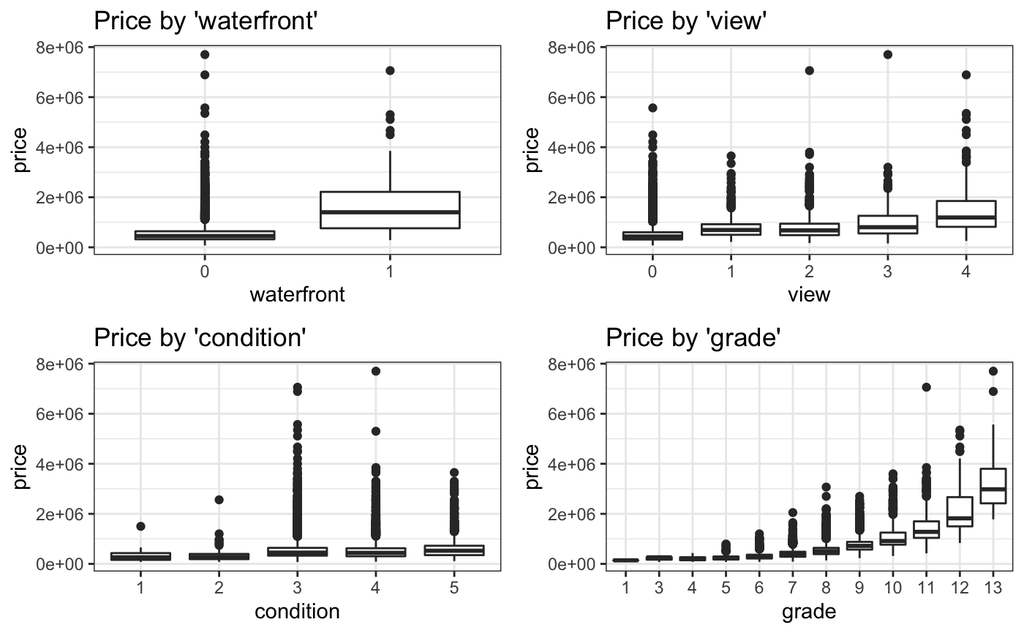

#### Mapping to binary classes and checking distributions and interactions

```r
# Changing `view` to 0 for regular view and 1 for every other view
house$view <- factor(ifelse(house$view!=0, 1, 0))
# Changing `condition` to 0 for everything below 3 and 1 otherwise
house$condition <- factor(ifelse(house$condition==1 | house$condition==2 | house$condition==3, 0, 1))
# Changing `grade` to 0 for everything below 7 and 1 otherwise
house$grade <- factor(ifelse(house$grade==1 | house$grade==2 | house$grade==3 |
                      house$grade==4 | house$grade==5 | house$grade==7 , 0, 1))
```

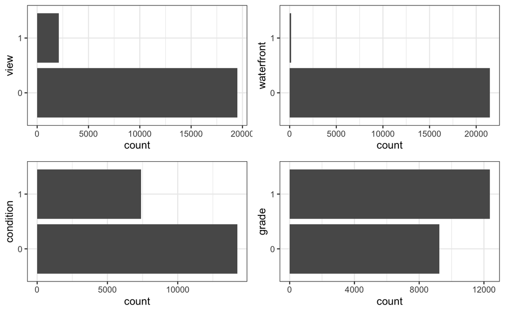

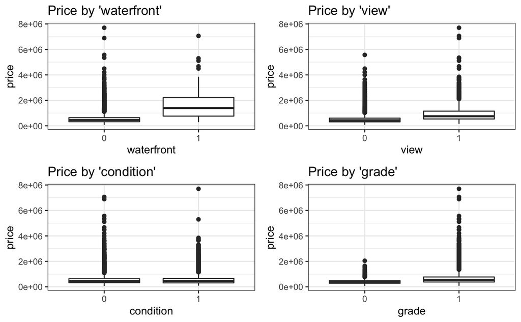

#### Checking possible interactions after mapping categorical variables to a larger classes

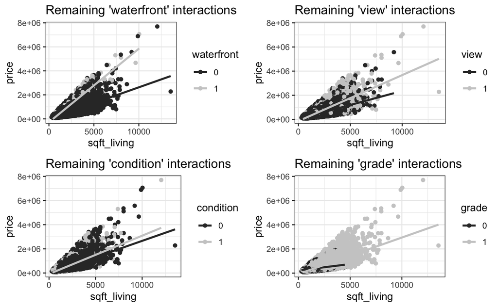

```r
##produce the 4 density plots in a 2 by 2 matrix
grid.arrange(sp1+scale_color_grey(),
             sp2+scale_color_grey(),
             sp3+scale_color_grey(),
             sp4+scale_color_grey(),
             ncol = 2,
             nrow = 2)
```

#### Final check, same scatter plots but with log(price) - no visiable interaction with log price.

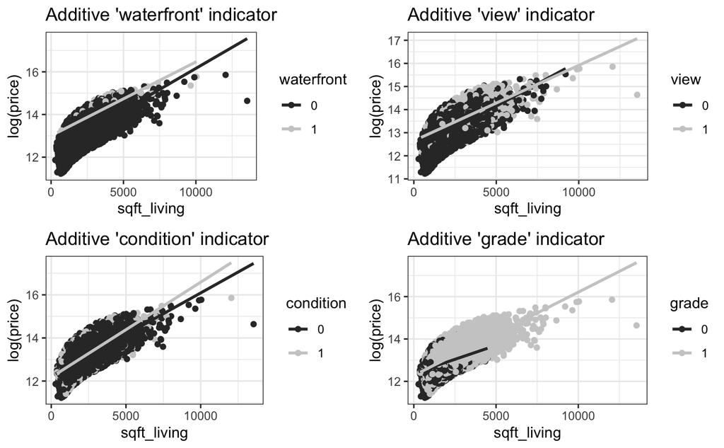

```r
##produce the 4 plots in a 2 by 2 matrix
grid.arrange(sp1+scale_color_grey(),
             sp2+scale_color_grey(),
             sp3+scale_color_grey(),
             sp4+scale_color_grey(),
             ncol = 2,
             nrow = 2)
```

#### Quantitative pridictors:

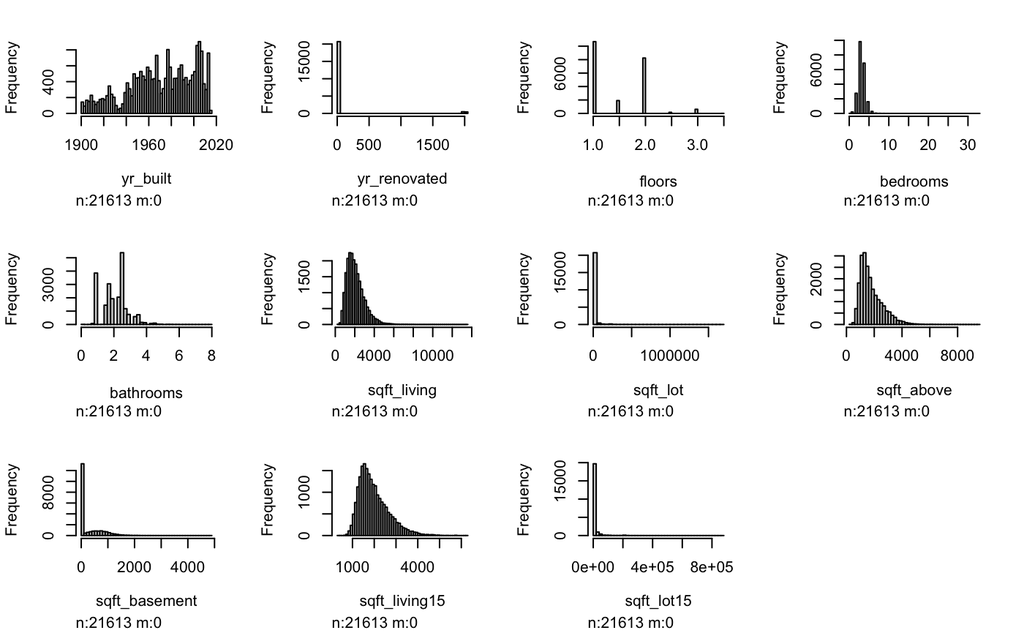

#### Checking how many quantitative observations have 0 values

```r
colSums(house[,quant_vars] == 0)
```

```
     yr_built  yr_renovated        floors      bedrooms     bathrooms   sqft_living      sqft_lot    sqft_above
            0         20699             0            13            10             0             0             0
sqft_basement sqft_living15    sqft_lot15
        13126             0             0
```

#### Some homes have no basements (more than 50%) also all homes are expected to have non-zero number of bedrooms (13 zeros) and bathrooms (10 zeroz). Drop sqft_basement column and bathroom/betroom rows with zeros:

```r
colSums(house[,quant_vars] == 0)
```

```
     yr_built  yr_renovated        floors      bedrooms     bathrooms   sqft_living      sqft_lot    sqft_above
            0         20683             0             0             0             0             0             0
sqft_basement sqft_living15    sqft_lot15
        13110             0             0
```

```r
names(house)
```

```
 [1] "price"         "bedrooms"      "bathrooms"     "sqft_living"   "sqft_lot"      "floors"        "waterfront"
 [8] "view"          "condition"     "grade"         "sqft_above"    "yr_built"      "yr_renovated"  "sqft_living15"
[15] "sqft_lot15"
```

#### Computing age of the house and removing year_build and year_renovated

|  | price | bedrooms | bathrooms | sqft_living | sqft_lot | floors | waterfront | view | condition | grade | sqft_above | yr_built | yr_renovated | sqft_living15 | sqft_lot15 | age |
| --- | --- | --- | --- | --- | --- | --- | --- | --- | --- | --- | --- | --- | --- | --- | --- | --- |
| 1 | 221900 | 3 | 1.00 | 1180 | 5650 | 1 | 0 | 0 | 0 | 0 | 1180 | 1955 | 0 | 1340 | 5650 | 66 |
| 2 | 538000 | 3 | 2.25 | 2570 | 7242 | 2 | 0 | 0 | 0 | 0 | 2170 | 1951 | 1991 | 1690 | 7639 | 30 |
| 3 | 180000 | 2 | 1.00 | 770 | 10000 | 1 | 0 | 0 | 0 | 1 | 770 | 1933 | 0 | 2720 | 8062 | 88 |
| 4 | 604000 | 4 | 3.00 | 1960 | 5000 | 1 | 0 | 0 | 1 | 0 | 1050 | 1965 | 0 | 1360 | 5000 | 56 |
| 5 | 510000 | 3 | 2.00 | 1680 | 8080 | 1 | 0 | 0 | 0 | 1 | 1680 | 1987 | 0 | 1800 | 7503 | 34 |
| 6 | 1230000 | 4 | 4.50 | 5420 | 101930 | 1 | 0 | 0 | 0 | 1 | 3890 | 2001 | 0 | 4760 | 101930 | 20 |

```r
names(house)
```

```
 [1] "price"         "bedrooms"      "bathrooms"     "sqft_living"   "sqft_lot"      "floors"        "waterfront"
 [8] "view"          "condition"     "grade"         "sqft_above"    "sqft_living15" "sqft_lot15"    "age"
```

#### Modified set of quantitative vars:

```
click left mouse button to proceed
```

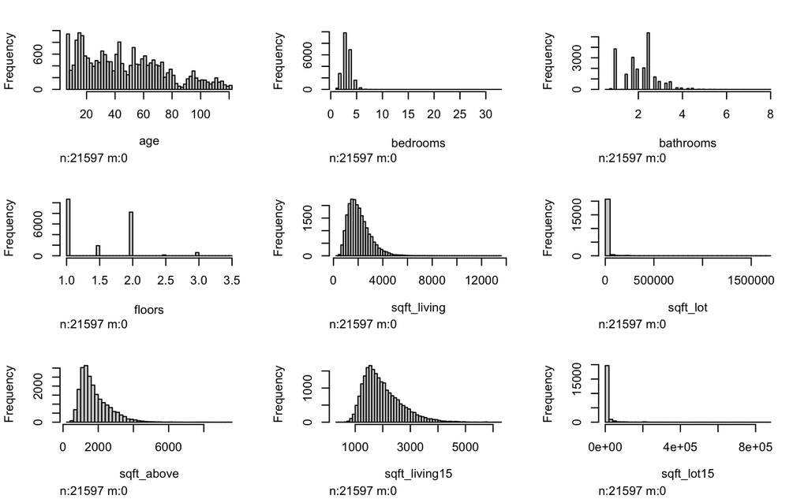

```r
hist.data.frame(house[,quant_vars])
```

#### Correlations of quantitative vars:

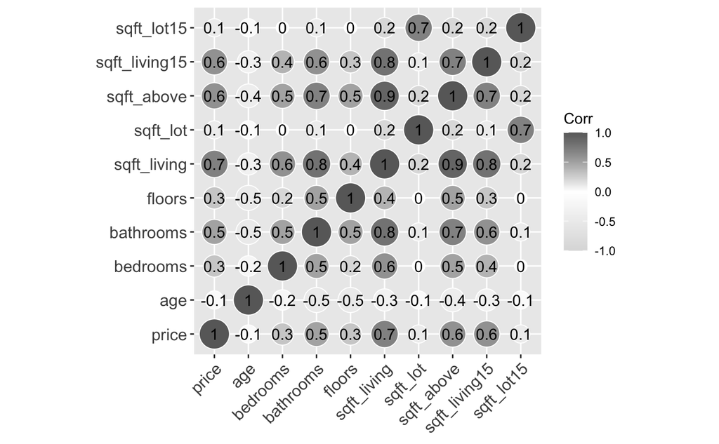

```r
ggcorrplot(corr,
           method = "circle",
           lab = TRUE,
          # type = "lower",
           outline.color = "white",
           ggtheme = ggplot2::theme_gray,
           colors = grey_shades)#c("#6D9EC1", "white", "#E46726"))
```

```r
str(house)
```

```
'data.frame':   21597 obs. of  13 variables:
 $ price        : num  221900 538000 180000 604000 510000 ...
 $ bedrooms     : int  3 3 2 4 3 4 3 3 3 3 ...
 $ bathrooms    : num  1 2.25 1 3 2 4.5 2.25 1.5 1 2.5 ...
 $ sqft_living  : int  1180 2570 770 1960 1680 5420 1715 1060 1780 1890 ...
 $ sqft_lot     : int  5650 7242 10000 5000 8080 101930 6819 9711 7470 6560 ...
 $ floors       : num  1 2 1 1 1 1 2 1 1 2 ...
 $ waterfront   : Ord.factor w/ 2 levels "0"<"1": 1 1 1 1 1 1 1 1 1 1 ...
 $ view         : Factor w/ 2 levels "0","1": 1 1 1 1 1 1 1 1 1 1 ...
 $ condition    : Factor w/ 2 levels "0","1": 1 1 1 2 1 1 1 1 1 1 ...
 $ grade        : Factor w/ 2 levels "0","1": 1 1 2 1 2 2 1 1 1 1 ...
 $ sqft_living15: int  1340 1690 2720 1360 1800 4760 2238 1650 1780 2390 ...
 $ sqft_lot15   : int  5650 7639 8062 5000 7503 101930 6819 9711 8113 7570 ...
 $ age          : num  66 30 88 56 34 20 26 58 61 18 ...
```

```r
#write_csv(house, 'house_data_cleaned.csv')
```

## TODO: interpreting models https://cran.r-project.org/web/packages/jtools/vignettes/summ.html

## Benchmark regression

```r
summary(fit)
```

```
Call:
lm(formula = log(price) ~ ., data = house)

Residuals:
     Min       1Q   Median       3Q      Max
-2.35054 -0.23684  0.01519  0.23396  1.85335

Coefficients:
                Estimate Std. Error t value Pr(>|t|)
(Intercept)    1.188e+01  2.076e-02 572.120  < 2e-16 ***
bedrooms      -4.325e-02  3.212e-03 -13.466  < 2e-16 ***
bathrooms      1.062e-01  5.473e-03  19.405  < 2e-16 ***
sqft_living    2.517e-04  5.304e-06  47.466  < 2e-16 ***
sqft_lot       1.787e-07  8.124e-08   2.199   0.0279 *
floors         1.228e-01  5.456e-03  22.507  < 2e-16 ***
waterfront.L   2.981e-01  1.982e-02  15.039  < 2e-16 ***
view1          1.654e-01  8.597e-03  19.240  < 2e-16 ***
condition1     3.985e-02  5.498e-03   7.247  4.4e-13 ***
grade1         8.486e-02  5.364e-03  15.820  < 2e-16 ***
sqft_living15  1.638e-04  5.376e-06  30.467  < 2e-16 ***
sqft_lot15    -8.820e-07  1.242e-07  -7.099  1.3e-12 ***
age            4.100e-03  1.101e-04  37.227  < 2e-16 ***
---
Signif. codes:  0 ‘***’ 0.001 ‘**’ 0.01 ‘*’ 0.05 ‘.’ 0.1 ‘ ’ 1

Residual standard error: 0.3429 on 21584 degrees of freedom
Multiple R-squared:  0.5763,    Adjusted R-squared:  0.576
F-statistic:  2446 on 12 and 21584 DF,  p-value: < 2.2e-16
```

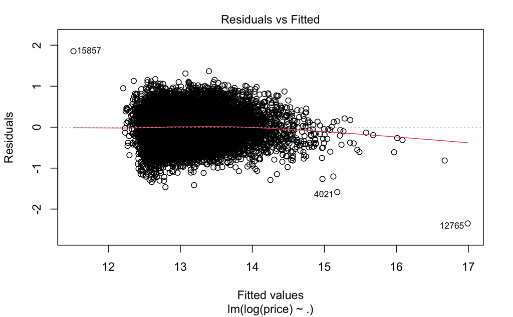

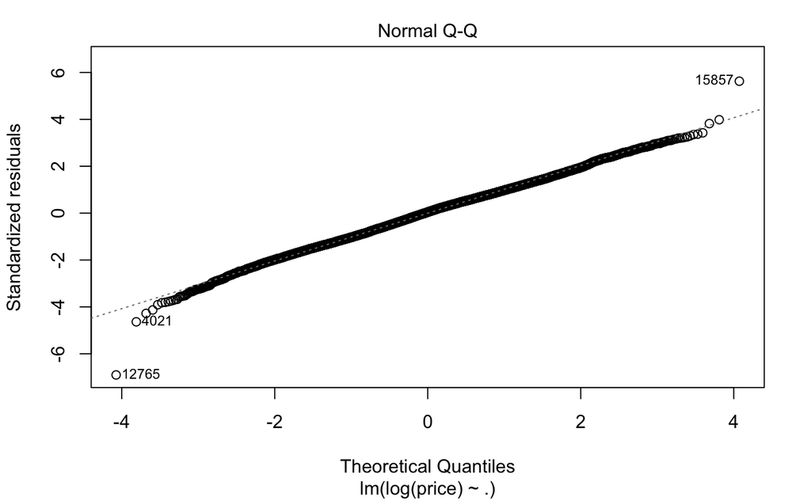

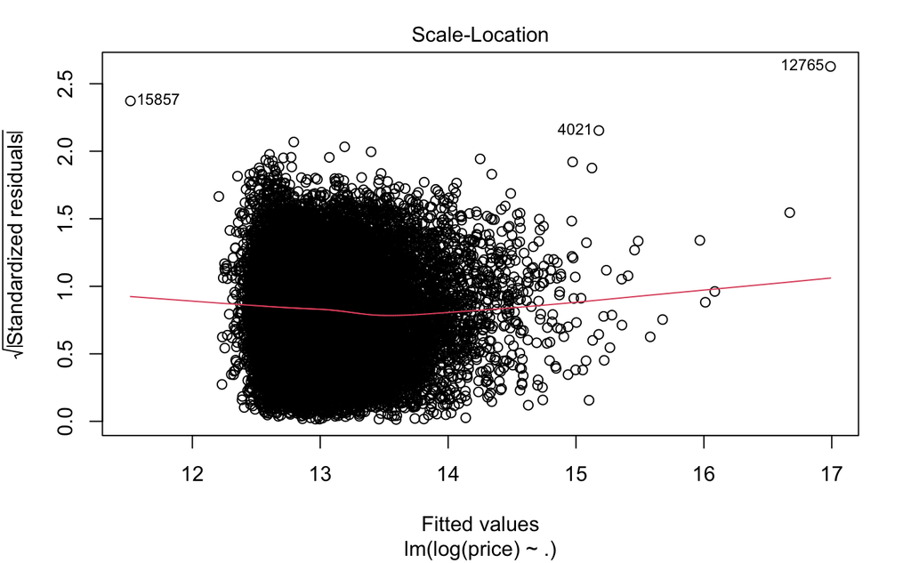

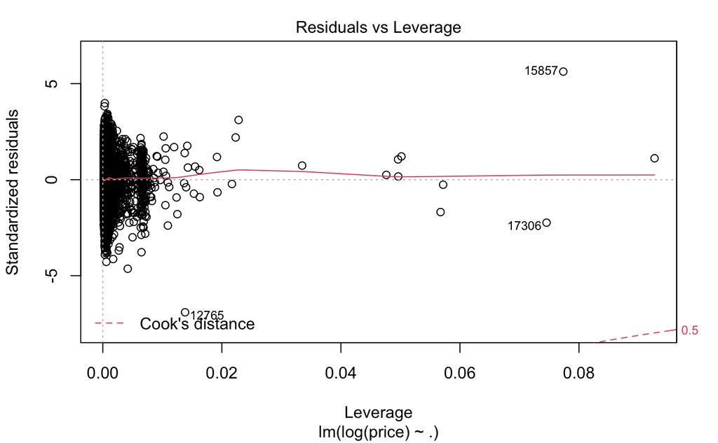